# Clustering

## Cong Zhang

### University of Baltimore

In this document, we will learn how to implement different types of clustering algorithms (k-Means, Agglomerative, and DBSCAN) in Python.

## k-Means Clustering

Let's start with the most straightforward one: k-Means clustering. As we learned from the slides, The algorithm alternates between two steps: assigning each data point to the closest cluster center, and then setting each cluster center as the mean of the data points that are assigned to it. The algorithm is finished when the assignment of instances to clusters no longer changes.

Applying k-means with sklearn is quite straightforward. We instantiate the KMeans class, and set the number of clusters we are looking for. Then we call the fit method with the data. Let's start by generating some blobs:

```python
from sklearn.datasets import make_blobs
import numpy as np
blob_centers = np.array(
    [[ -3,  3],
     [ -3 , 1],
     [ 0,  2],
     [ 3,  3],
     [ 3,  1]])
blob_std = np.array([0.1, 0.1, 0.1, 0.1, 0.1])
X, y = make_blobs(n_samples=2000, centers=blob_centers,
                  cluster_std=blob_std, random_state=7)
```

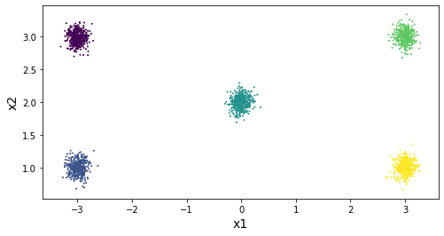

```python
# Plot the data out
import matplotlib.pyplot as plt
def plot_clusters(X, y=None):
    plt.scatter(X[:, 0], X[:, 1], c=y, s=1)
    plt.xlabel("x1", fontsize=14)
    plt.ylabel("x2", fontsize=14)

plt.figure(figsize=(8, 4))
plot_clusters(X,y)
plt.show()
```

#### Fit and predict

Let's train a K-Means clusterer on this dataset. It will try to find each blob's center and assign each instance to the closest blob:

```python
from sklearn.cluster import KMeans
#It shows there are 5 clusters
k = 5
kmeans = KMeans(n_clusters=k, random_state=42)
y_pred = kmeans.fit_predict(X)
#Each instance was assigned to one of the 5 clusters
print(y_pred)
```

```
[4 2 3 ... 1 3 2]
```

```python
#The following 5 centroids (i.e., cluster centers) were estimated:
print(kmeans.cluster_centers_)
#Compared with the true centroids, they are very much close.
```

```
[[-2.99431593  0.99645029]
 [ 2.99906525  2.9981683 ]
 [-0.00705801  2.00047064]
 [-2.9999686   2.98865535]
 [ 2.99977791  1.00135806]]
```

```python
# Use the model to label new instances:
X_new = np.array([[0, 2], [3, 2], [-3, 3], [-3, 2.5]])
kmeans.predict(X_new)
```

```
array([2, 1, 3, 3])
```

#### Finding the Optimal Number of Cluster: inertia

As we learned from the slides, one of the method to find the optimal number of cluster is to find the "elbow point" for the plot of inertia values. Let's plot the inertia as a function of the number of clusters (k) and analyze the resulting curve:

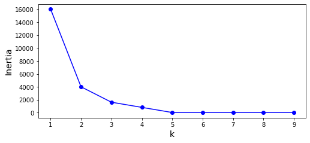

```python
#Fit 10 models with k from 1 to 10
kmeans_per_k = []
for k in range (1,10):
    model = KMeans(n_clusters = k, random_state=42).fit(X)
    kmeans_per_k.append(model)

#Store the inertias in a list
inertias = []
for model in kmeans_per_k:
    inertias.append(model.inertia_)

plt.figure(figsize=(8, 3.5))
plt.plot(range(1, 10), inertias, "bo-")
plt.xlabel("k", fontsize=14)
plt.ylabel("Inertia", fontsize=14)
plt.show()
```

As you can see, there is an elbow at k=5, which means that less clusters than that would be bad, and more clusters would not help much and might cut clusters in half. So k=5 is a best choice. However, in reality, most data is not distributed as clear as this example. Therefore, it will need your subjective judgements to decide the optimal number of clusters.

#### Finding the Optimal Number of Cluster: silhouette score

Another approach is to look at the silhouette score. The silhouette coefficient can vary between -1 and +1: a coefficient close to +1 means that the instance is well inside its own cluster and far from other clusters.

Let's plot the silhouette score as a function of k:

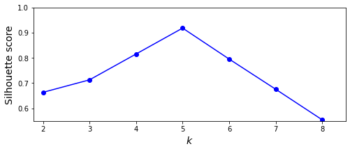

```python
from sklearn.metrics import silhouette_score
silhouette_scores = []
for model in kmeans_per_k[1:]:
    silhouette_scores.append(silhouette_score(X, model.labels_))

plt.figure(figsize=(8, 3))
plt.plot(range(2, 10), silhouette_scores, "bo-")
plt.xlabel("$k$", fontsize=14)
plt.ylabel("Silhouette score", fontsize=14)
plt.axis([1.8, 8.5, 0.55, 1])
plt.show()
```

## Agglomerative Clustering

As we learned from the slides, the agglomerative clsutering algorithm starts by identifying each data point as a single cluster and gradually merges two most similar clsuters until the stopping criterion, such as the number of clusters, is met.

Let’s have a look at how agglomerative clustering performs on a simple three cluster data. Because of the way the algorithm works, agglomerative clustering cannot make predictions for new data points. Therefore, Agglomerative Clustering has no "predict" method. To build the model and get the cluster memberships on the training set, use the fit_predict method instead.

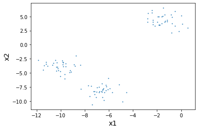

```python
#Create a random data
X, y = make_blobs(random_state=1)
plot_clusters(X)
plt.show()
```

```python
#Fit an agglomerative clustering model
from sklearn.cluster import AgglomerativeClustering
agg = AgglomerativeClustering(n_clusters=3)
# we call it 'assignmnets' becausae agglomeratives can't make predictions
assignment = agg.fit_predict(X)
#Group assignments
print(assignment)
# big importnat note : We can not make predictions using allgomerative clustering (agg.)
# our output box shoul be a list of zeros, ones, and twos representing the 3 clusters from the above 'blobs'cluster
# used to  extend the view of scope of the entire process, to clumsly to do predictions,
# not accurate enough...weak explanation but read books
```

```
[0 2 2 2 1 1 1 2 0 0 2 2 1 0 1 1 1 0 2 2 1 2 1 0 2 1 1 0 0 1 0 0 1 0 2 1 2
 2 2 1 1 2 0 2 2 1 0 0 0 0 2 1 1 1 0 1 2 2 0 0 2 1 1 2 2 1 0 1 0 2 2 2 1 0
 0 2 1 1 0 2 0 2 2 1 0 0 0 0 2 0 1 0 0 2 2 1 1 0 1 0]
```

### Dendrogram

Now, let's use the dengrogram to visualize the process of an agglomerative clustering.

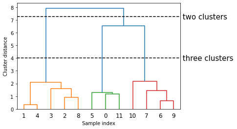

```python
# Import the dendrogram function and the ward clustering function from SciPy
from scipy.cluster.hierarchy import dendrogram, ward

X, y = make_blobs(random_state=0, n_samples=12)
# Apply the ward clustering to the data array X
# The SciPy ward function returns an array that specifies the distances
# bridged when performing agglomerative clustering
linkage_array = ward(X)
# Now we plot the dendrogram for the linkage_array containing the distances
# between clusters
dendrogram(linkage_array)

# mark the cuts in the tree that signify two or three clusters
ax = plt.gca()
bounds = ax.get_xbound()
ax.plot(bounds, [7.25, 7.25], '--', c='k')
ax.plot(bounds, [4, 4], '--', c='k')
# The next few lines are usefull to a data scientist to know because these are the variables that will be swapped
# out repeatdely to make a dendogram,which is the easiest model for non data scientists to quickly read or understand visually.
ax.text(bounds[1], 7.25, ' two clusters', va='center', fontdict={'size': 15})
ax.text(bounds[1], 4, ' three clusters', va='center', fontdict={'size': 15})
plt.xlabel("Sample index")
plt.ylabel("Cluster distance")
```

Now, recall what we learned from the slides. The dendrogram shows data points as points on the bottom (numbered from 0 to 11). Then, a tree is plotted with these points (representing single-point clusters) as the leaves, and a new node parent is added for each two clusters that are joined.

Reading from bottom to top, the data points 1 and 4 are joined first (as you could see in the figure above). Next, points 6 and 9 are joined into a cluster, and so on. At the top level, there are two branches, one consisting of points 11, 0, 5, 10, 7, 6, and 9, and the other consisting of points 1, 4, 3, 2, and 8. These correspond to the two largest clusters in the lefthand side of the plot.

The y-axis in the dendrogram doesn’t just specify when in the agglomerative algorithm two clusters get merged. The length of each branch also shows how far apart the merged clusters are. The longest branches in this dendrogram are the three lines that are marked by the dashed line labeled “three clusters.” That these are the longest branches indicates that going from three to two clusters meant merging some very far-apart points. We see this again at the top of the chart, where merging the two remaining clusters into a single cluster again bridges a relatively large distance.

## DBSCAN

Now, let's take a look at how to use DBSCAN for more complex data patterns. This can be done using the sklearn library:

```python
from sklearn.cluster import DBSCAN
```

Then, let's try DBSCAN on a clasic double-moon data, which k-means and agglomarative clusterings tend to perform poorly on.

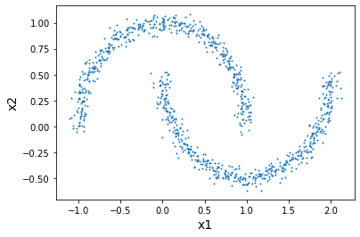

```python
from sklearn.datasets import make_moons
X, y = make_moons(n_samples=1000, noise=0.05, random_state=42)
plot_clusters(X)
plt.show()
```

As you can tell from the previous figure, the two clusters are like two moons cross together. As we learned from the slides, traditional clusters perform badly on when the clusters are nonspherical shapes. In this case, DBSCAN comes for rescure. Let's first build and fit an DBSCAN model:

```python
#The two parameters are eps and min_samples
dbscan = DBSCAN(eps=0.05, min_samples=5)
dbscan.fit(X)
#The labels of all the instances are now available in the labels_ instance variable:
print(dbscan.labels_[:10])
#Notice that some instances have a cluster index equal to –1, which means that they
#are considered as anomalies by the algorithm.
# anamoiles are treated as noise and they are very far away from any of the other clusters.
```

```
[ 0  2 -1 -1  1  0  0  0  2  5]
```

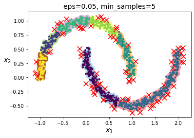

```python
#Let's plot them out!
def plot_dbscan(dbscan, X, size, show_xlabels=True, show_ylabels=True):
    core_mask = np.zeros_like(dbscan.labels_, dtype=bool)
    core_mask[dbscan.core_sample_indices_] = True
    anomalies_mask = dbscan.labels_ == -1
    non_core_mask = ~(core_mask | anomalies_mask)

    cores = dbscan.components_
    anomalies = X[anomalies_mask]
    non_cores = X[non_core_mask]

    plt.scatter(cores[:, 0], cores[:, 1],
                c=dbscan.labels_[core_mask], marker='o', s=size, cmap="Paired")
    plt.scatter(cores[:, 0], cores[:, 1], marker='*', s=20, c=dbscan.labels_[core_mask])
    plt.scatter(anomalies[:, 0], anomalies[:, 1],
                c="r", marker="x", s=100)
    plt.scatter(non_cores[:, 0], non_cores[:, 1], c=dbscan.labels_[non_core_mask], marker=".")
    if show_xlabels:
        plt.xlabel("$x_1$", fontsize=14)
    else:
        plt.tick_params(labelbottom=False)
    if show_ylabels:
        plt.ylabel("$x_2$", fontsize=14, rotation=0)
    else:
        plt.tick_params(labelleft=False)
    plt.title("eps={:.2f}, min_samples={}".format(dbscan.eps, dbscan.min_samples), fontsize=14)

plot_dbscan(dbscan, X, size=100)
plt.show()
```

From the figure above, we can tell the results are somewhat disappointing. As you can see, it identified quite a lot of anomalies, plus seven different clusters. It's ok, we just need to try different parameters. The reason it gives us seven clusters is because our criteria are too strict (i.e., at least 5 instances within 0.05 distance). As a result, when places in the same cluster with low densities, they will be identified as different clusters.

Let's try to increase the distance from 0.05 to 0.2:

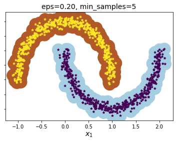

```python
dbscan2 = DBSCAN(eps=0.2, min_samples=5)
dbscan2.fit(X)
plot_dbscan(dbscan2, X, size=600, show_ylabels=False)
plt.show()
```

Now, the results are much better. Two clusters are clearly identified with boundary points around.

## Evaluate Clustering Algorithms

We have learned three different clustering algorithms: k-means, agglomarative, and DBSCAN. Now, let's look at how to evaluate their performance. Unlike supervised learning methods, we cannot use metrics reflecting predictive accuracies or errors since there is no known labels for the unsupervised learning models. There are different ways of evaluating clustering models' performance.

#### Evaluate with ground truth

As we learned from the slides, if we know the ground truth for the clusters. we can use the adjusted rand index (ARI) and normalized mutal information (NMI). Here, we compare the k-means, agglomerative clustering, and DBSCAN algorithms using ARI on the double-moon data. We also include what it looks like when we randomly assign points to two clusters for comparison:

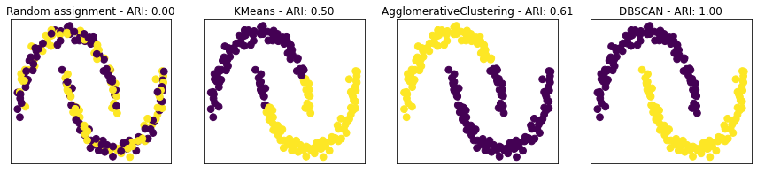

```python
from sklearn.preprocessing import StandardScaler
from sklearn.metrics.cluster import adjusted_rand_score
X, y = make_moons(n_samples=200, noise=0.05, random_state=0)
# rescale the data to zero mean and unit variance
scaler = StandardScaler()
scaler.fit(X)
X_scaled = scaler.transform(X)
fig, axes = plt.subplots(1, 4, figsize=(15, 3),
subplot_kw={'xticks': (), 'yticks': ()})

# make a list of algorithms to use
algorithms = [KMeans(n_clusters=2), AgglomerativeClustering(n_clusters=2),
             DBSCAN()]

# create a random cluster assignment for reference
random_state = np.random.RandomState(seed=0)
random_clusters = random_state.randint(low=0, high=2, size=len(X))

# plot random assignment
axes[0].scatter(X_scaled[:, 0], X_scaled[:, 1], c=random_clusters, s=60)
axes[0].set_title("Random assignment - ARI: {:.2f}".format(
                    #It requires a known "y"
                    adjusted_rand_score(y, random_clusters)))

for ax, algorithm in zip(axes[1:], algorithms):
    # plot the cluster assignments and cluster centers
    clusters = algorithm.fit_predict(X_scaled)
    ax.scatter(X_scaled[:, 0], X_scaled[:, 1], c=clusters, s=60)
    ax.set_title("{} - ARI: {:.2f}".format(algorithm.__class__.__name__,
                                            adjusted_rand_score(y, clusters)))
```

As you can see, the random cluster assignment having a score of 0 and DBSCAN (which recovers the desired clustering perfectly) having a score of 1.

#### Evaluate without ground truth

When applying clustering algorithms, there is usually no ground truth to which to compare the results. If we knew the right clustering of the data, we could use this information to build a supervised model like a classifier. Therefore, using metrics like ARI and NMI usually only helps in developing algorithms, not in assessing success in an application.

There are scoring metrics for clustering that don’t require ground truth, like the silhouette coefficient. Here is an example comparing the outcome of k-means, agglomerative clustering, and DBSCAN on the double-moons dataset using the silhouette score:

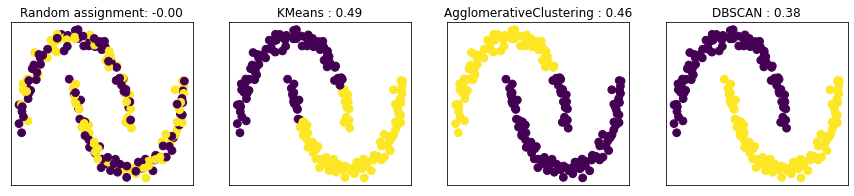

```python
from sklearn.metrics.cluster import silhouette_score

X, y = make_moons(n_samples=200, noise=0.05, random_state=0)

# rescale the data to zero mean and unit variance
scaler = StandardScaler()
scaler.fit(X)
X_scaled = scaler.transform(X)

fig, axes = plt.subplots(1, 4, figsize=(15, 3),
                         subplot_kw={'xticks': (), 'yticks': ()})

# create a random cluster assignment for reference
random_state = np.random.RandomState(seed=0)
random_clusters = random_state.randint(low=0, high=2, size=len(X))

# plot random assignment
axes[0].scatter(X_scaled[:, 0], X_scaled[:, 1], c=random_clusters,s=60)
axes[0].set_title("Random assignment: {:.2f}".format(
    #It does not require a known "y"
    silhouette_score(X_scaled, random_clusters)))

algorithms = [KMeans(n_clusters=2), AgglomerativeClustering(n_clusters=2),
              DBSCAN()]

for ax, algorithm in zip(axes[1:], algorithms):
    clusters = algorithm.fit_predict(X_scaled)
    # plot the cluster assignments and cluster centers
    ax.scatter(X_scaled[:, 0], X_scaled[:, 1], c=clusters, s=60)
    ax.set_title("{} : {:.2f}".format(algorithm.__class__.__name__,
                                      silhouette_score(X_scaled, clusters)))
```

As you can see, k-means gets the highest silhouette score, even though we might prefer the result produced by DBSCAN. Thus, it is challenging to evaluate and compare unsupervised learning methods' performance. The best way is probably to visualize the plots.

## Exercise: Clustering on the Faces Dataset

In the exercise, let's apply the k-means, DBSCAN, and agglomerative clustering algorithms to the labeled Faces in the Wild dataset. First, run the following cell to import and preprocess the data.

```python
# extract eigenfaces from lfw data and transform data
from sklearn.decomposition import PCA
from sklearn.datasets import fetch_lfw_people

people = fetch_lfw_people(min_faces_per_person=20, resize=0.7)
mask = np.zeros(people.target.shape, dtype=np.bool)
for target in np.unique(people.target):
    mask[np.where(people.target == target)[0][:50]] = 1

X_people = people.data[mask]
y_people = people.target[mask]

# scale the grey-scale values to be between 0 and 1
# instead of 0 and 255 for better numeric stability:
X_people = X_people / 255.
#Reduce the dimensionalities of the data to accelerate the process.
pca = PCA(n_components=100, whiten=True, random_state=0)
X_prepared = pca.fit_transform(X_people)
```

### Exercise Question 1

Build a DBSCAN model with the min_samples = 3 and eps = 7, and name the model as "dbscan". Fit the "dbscan" model using the fit_predict() function to get the assignment results, and name the results as "labels_dbscan". The data is created in the cell above, namely "X_prepared".

```python
#Type your answers for question 1 here:
#1. Create a DBSCAN model and name it as "dbscan"
dbscan = DBSCAN(eps=7, min_samples=3)
#2. Fit the "dbscan" model and name the results as "labels_dbscan"
labels_dbscan = dbscan.fit_predict(X_prepared)
print(labels_dbscan)
```

```
[-1 -1 -1 ... -1 -1 -1]
```

If your answers above are correct with the right names, you should be able to run the following cell and visualize the clustering results.

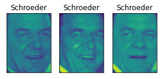

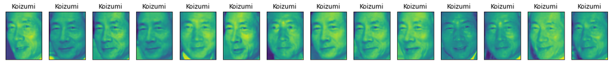

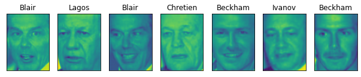

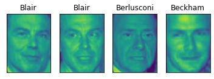

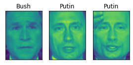

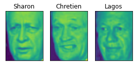

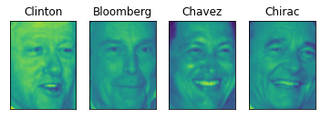

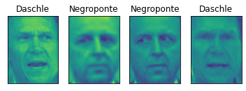

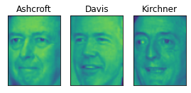

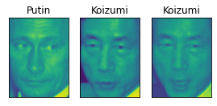

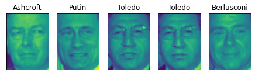

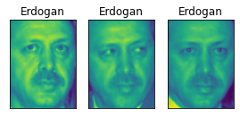

[1 more figures not shown]

```python
noise = X_people[labels_dbscan==-1]
image_shape = people.images[0].shape
for cluster in range(max(labels_dbscan) + 1):
    mask = labels_dbscan == cluster
    n_images =  np.sum(mask)
    fig, axes = plt.subplots(1, n_images, figsize=(n_images * 1.5, 4),
                             subplot_kw={'xticks': (), 'yticks': ()})
    for image, label, ax in zip(X_people[mask], y_people[mask], axes):

        ax.imshow(image.reshape(image_shape), vmin=0, vmax=1)
        ax.set_title(people.target_names[label].split()[-1])
```